# EM_S23_Week1

Rosalee Elting

2023-01-19

# Week 1 - Day 1

### Writing a Michaelis-Menten Function

Fixed Values: Umax = 1 Ks = 100 Formula U = Umax S / Ks + S

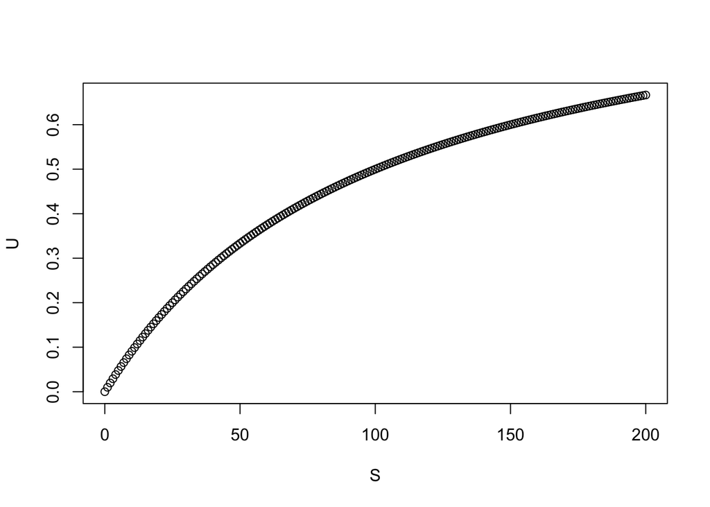

```r
mm_function <- function(Um, Ks, S){
 U <- Um*S/(Ks+S)
 plot(S,U)
 }
S <- seq(from = 0, to = 200, by = 1)
mm_function(Um =1, Ks = 100, S = S)
```

### Using a Threshold Switching Equation x = sequence from 1 to 30 Tao = 17 g1 y = b g2 y = ax+b b = 10 a = 5

Here is the structure of the argument I should use. ifelse(condition- a Boolean statement , value 1, value 2) The condition: X is <17 or >=17

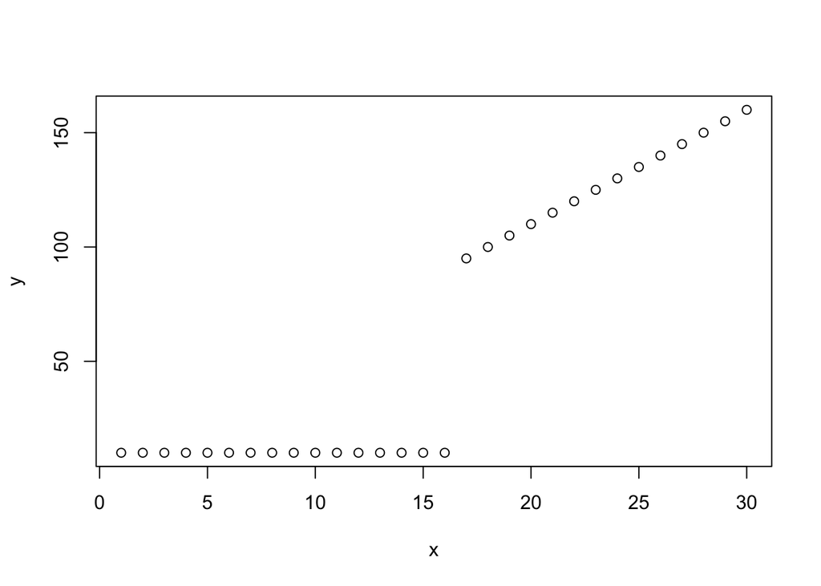

```r
x <- seq(1:30)
a <- 5
b <- 10
y <- ifelse(x >= 17, a*x+b, b)

plot(x, y)
```

### Week 1 - Day 1 Homework #### For Loops Gotelli - Basic Anatomy and Use of For Loops

for(var in seq) { Body for the loop, often the call to a function }

var is a counter variable that holds the current values of the counter in the loop Seq is an integer vector (defines start and end values of the loop)

i,j,k for var (counter)

Using seq_along(df) is a safe way to do rather than length(df) so that it won’t retun a result if vector is blank.

Loop tips: Do NOT change object dimenstion inside a loop Avoid these functions: cbind, rbind, c, list

```r
my_dogs <- (c("chow", "akita", "malamute", "husky", "samoyed"))

for(i in seq_along(my_dogs)) {
  cat("i =", i, "my_dogs[i] =", my_dogs[i], "\n")
}
```

```
## i = 1 my_dogs[i] = chow
## i = 2 my_dogs[i] = akita
## i = 3 my_dogs[i] = malamute
## i = 4 my_dogs[i] = husky
## i = 5 my_dogs[i] = samoyed
```

```r
my_bad_dogs <- NULL
for (i in seq_along(my_bad_dogs)) {
  cat("i =", i, "my_bad_dogs[i] =", my_bad_dogs[i], "\n")
}
```

Can define vector length from a constant

```r
zz <- 5
for( i in seq_len(zz)) {
  cat("i =", i, "my_dogs[i] =", my_dogs[i], "\n")
  }
```

```
## i = 1 my_dogs[i] = chow
## i = 2 my_dogs[i] = akita
## i = 3 my_dogs[i] = malamute
## i = 4 my_dogs[i] = husky
## i = 5 my_dogs[i] = samoyed
```

#### If Else Function

Format: ifelse(test, yes, no) test is an object that can be coerced into a logical true/false for each element in the vector Yes returns values for true elements in the test no returns values for fasle elements in the test

Examples: suppose we have an insect pop in which each female lays on average 10.2 eggs, following a Poisson distribution. lambda = 10.2 here. However, there is a 35% chance of parasatism, in which case no eggs are laid. Here is a random sample of eggs laid for a group of 1000 individuals.

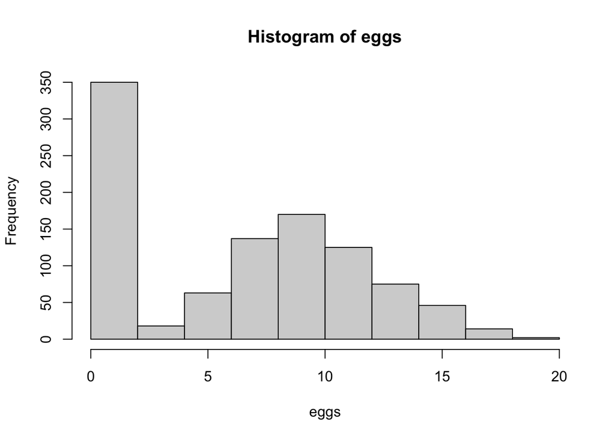

```r
#makes 1000 random uniform values
tester <- runif(1000)
eggs <- ifelse(tester > 0.35, rpois(n=1000, lambda=10.2), 0)
hist(eggs)
```

This produces a mixture model where there is a peak at ~10.2. Also a spike at zero, which represents the 0s created from Poisson itself, but also the 35% of individuals that didn’t reproduce due to parasitism.

Example 2: Suppose we have a vector of probability values (such as from a simulation). We want to highlight significant values in the vector for plotting

```r
p_vals <- runif(1000)
z <- ifelse(p_vals <=0.025, "lower_tail", "non_significant")
z[p_vals >=0.975] <- "upper_tail"

table(z)
```

```
## z
##      lower_tail non_significant      upper_tail
##              27             942              31
```

# Week 1 - Day 2

### Dyanmic Models - Exponential growth model

Formula: Nt = N0 e^kt Known values: K = 0.05 N0 =10

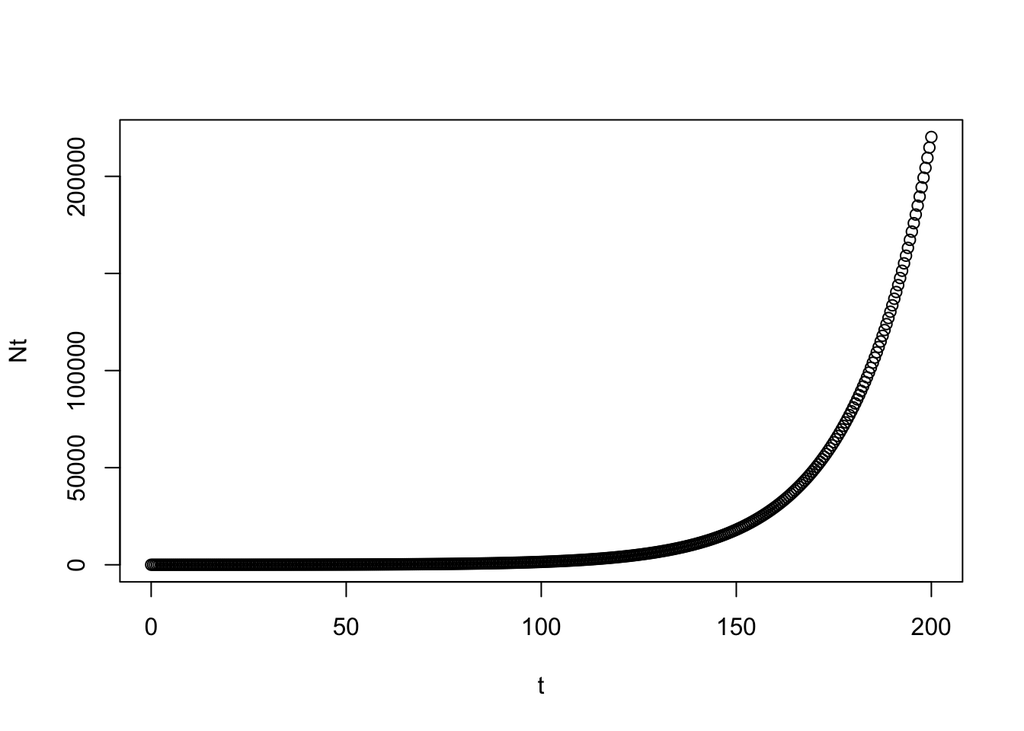

```r
#as a function
dyn_function <- function(K,N0){
 Nt <- N0*exp(K*t)
 plot(t,Nt)
}
t <- seq(from = 0, to = 200, by = 0.5)
dyn_function(K=0.05, N0= 10)

#not as a function, as a single vector.
N0 <- 10
K <- .05
t <- seq(from =0, to = 200, by = 0.5)
Nt <- N0*exp(K*t)
plot(t, Nt)
```

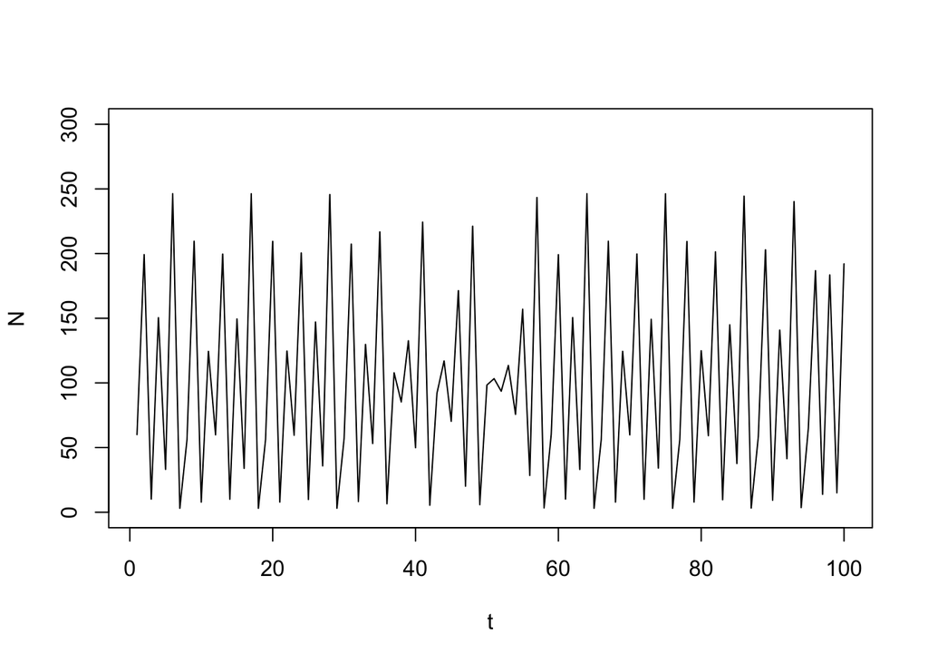

```r
#t <- seq(0:100)
k <- 100
r <- 3.0
N <- NA
N[1] <- 60
t <- seq(1:100)

#the below works, but I also want to standardize the way I assigned the length so it's not fixed in the loop but rather pre-assigned.

# for(i in 2:100) {
#   N[i] <- N[i-1]*exp(r*(1-N[i-1]/k))
# }

for(i in 2:length(t-1)) {
  N[i] <- N[i-1]*exp(r*(1-N[i-1]/k))
}
#plotting N over time
plot(t, N, type = "l", ylim = c(0,300))
```

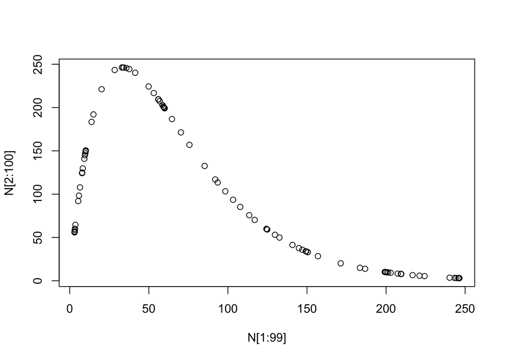

```r
#plotting Nt vs Nt-1 as a plot. This is following a pattern and deterministic, even though prior graph looks like pure chaos.
# Phase-space diagram
plot(N[1:99], N[2:100])
```

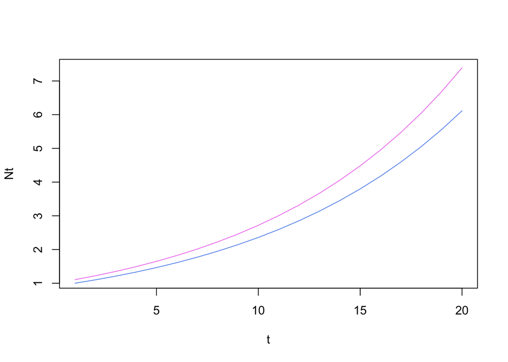

```r
K <- 0.1

NNt <- NA
NNt[1] <- 1
N0 <- 1
t <- seq(from =1, to = 20, by = 1)
#exponential
ENt <- N0*exp(K*t)
#numerical integration
for(i in 2:length(t-1)) {
  NNt[i] <- NNt[i-1]+K*NNt[i-1]*1
}

#N[i] <- N[i-1]*exp(r*(1-N[i-1]/k))
plot(t, ENt, type= "line", col = "violet",ylab = "Nt")
lines(t, NNt, col= "cornflowerblue")
```

### Numerical Integration of Lotka- Volterra Model Formulas: Nt = Nt-1 + (rNt-1 - aNt-1Pt-1) delta t Pt = Pt-1+ (abNt-1 Pt-1 - sPt-1) delta t Known values : delta t = 0.1 length of run = 2000 n[1] = 20 p[1] = 1 r = 0.04 a = 0.005 s= 0.1

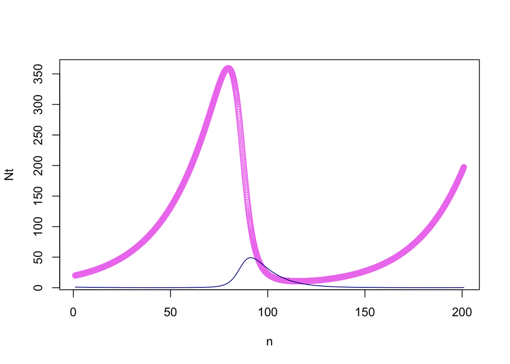

```r
n <- seq(from = 1, to = 200.9, by =0.1)
Nt <- NA
Nt[1] <- 20
Pt <- NA
Pt[1] <- 1
r <- 0.04
a <- 0.005
b <- 0.2
s <- 0.1
deltat <- 0.1

for (i in 2:length(n)) {
  Nt[i] <- Nt[i-1] + (r*Nt[i-1] - a*Nt[i-1]*Pt[i-1])*(n[i]-n[i-1])
  Pt[i] <- Pt[i-1] + (a*b*Nt[i-1]*Pt[i-1]- s*Pt[i-1])*(n[i]-n[i-1])
}

plot(n, Nt, col = "violet",ylab = "Nt")
lines(n, Pt, col= "darkblue")
```

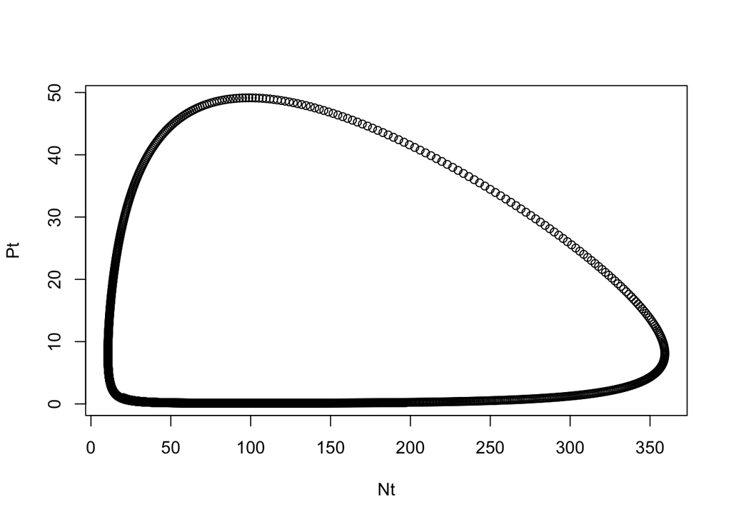

```r
#phase diagram is a circle
#there is an equilibrium that exists in the center of this circle. As N goes up, then P catches, and raises until N decreases and P does again.
plot(Nt, Pt)
```